# Parcela subdividida

Eric Gorgens

1/17/2021

No delineamento em parcelas subdivididas existem dois tipos de tratamento: o principal e o secundário. As parcelas são subdivididas no espaço, ou no tempo. Depois que os tratamentos principais são sorteados nas parcelas, sorteia-se o tratamento secundário nas subparcelas de cada parcela.

Indica-se o uso de parcelas subdivididas quando:

1. A parcela é uma “unidade” que pode receber vários tratamentos secundários. No setor florestal esta unidade pode ser uma vaso, ou mesmo uma árvore.
2. Não é possível instalar o experimento no esquema fatorial.
3. O tratamento principal exige parcelas custosas, seja do ponto de vista financeiro ou do esforço.
4. A busca pela precisão está no tratamento secundário.
5. Deseja-se que a Variação entre subparcelas seja menor que entre as parcelas.

O modelo estatístico do delineamento fatorial duplo inteiramente casualizado é:

$$Y = Xmed + BLOCO + TRAT A + Erro Parcela + TRAT B + (TRAT A * TRAT B) + Erro Subparcela$$

## O caso balanceado

Como exemplo de um desenho de parcela subdividida balanceado, vamos analisar um experimento de regeneração natural do sub bosque de três formações florestais. Nas parcelas de cada uma das área naturais estudadas, implantaram-se subparcelas correspondendo a três alturas de desrama. O efeito dos tratamentos foi medido através do número de indivíduos regenerantes.

- Fator na parcela: Floresta A, B e C
- Fator nas subparcelas: Desrama 2, 5 e 7 metros
- 3 repetições
- Variável de interesse: número de indivíduos regenerantes

Dados de experimento em parcela subdividida

| floresta | rep | desrama | indiv |
| --- | --- | --- | --- |
| A | 1 | 2 | 48 |
| A | 2 | 2 | 47 |
| A | 3 | 2 | 47 |
| A | 1 | 5 | 79 |
| A | 2 | 5 | 62 |
| A | 3 | 5 | 65 |
| A | 1 | 7 | 101 |
| A | 2 | 7 | 105 |
| A | 3 | 7 | 112 |
| B | 1 | 2 | 90 |
| B | 2 | 2 | 97 |
| B | 3 | 2 | 114 |
| B | 1 | 5 | 123 |
| B | 2 | 5 | 145 |
| B | 3 | 5 | 122 |
| B | 1 | 7 | 172 |
| B | 2 | 7 | 157 |
| B | 3 | 7 | 177 |
| C | 1 | 2 | 100 |
| C | 2 | 2 | 101 |
| C | 3 | 2 | 103 |
| C | 1 | 5 | 130 |
| C | 2 | 5 | 133 |
| C | 3 | 5 | 140 |
| C | 1 | 7 | 144 |
| C | 2 | 7 | 147 |
| C | 3 | 7 | 148 |

O primeiro passo é importar o arquivo csv contendo os resultados do experimento para dentro do R. Esta tarefa pode ser realizada através do seguinte comando:

```r
sub = read.csv("./data/Experimento Subdividida.csv",
               sep = ",", dec = ".")
```

Você já sabe! Antes de ir para análise estatística explore graficamente seus dados. Veja alguns exemplos de gráficos que podem ajudá-lo a construir suas hipóteses e antecipar os resultados que serão apresentados pelas análise estatística:

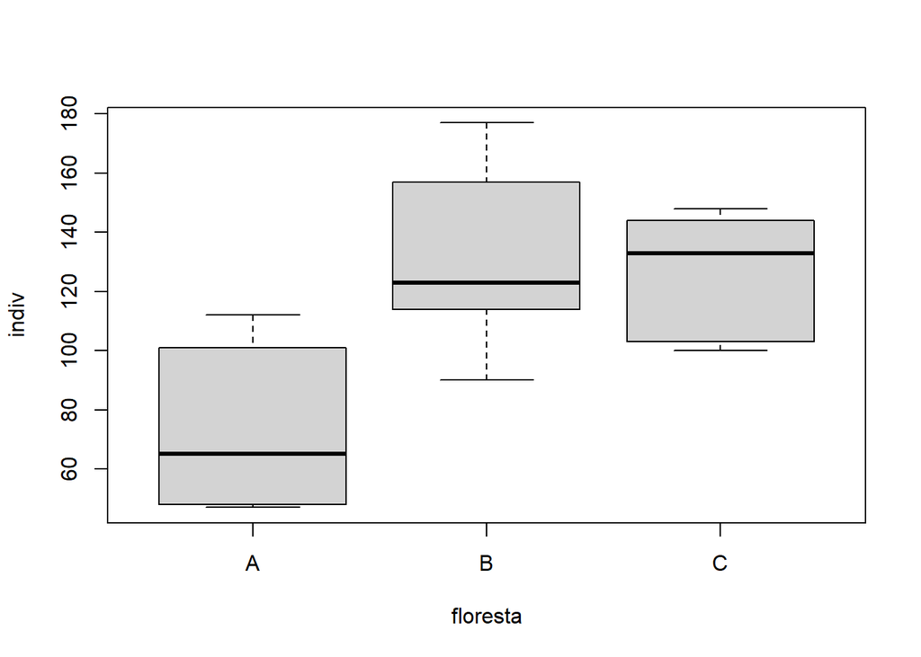

```r
# Considerando apenas tratamento principal
boxplot(data = sub, indiv ~ floresta)
```

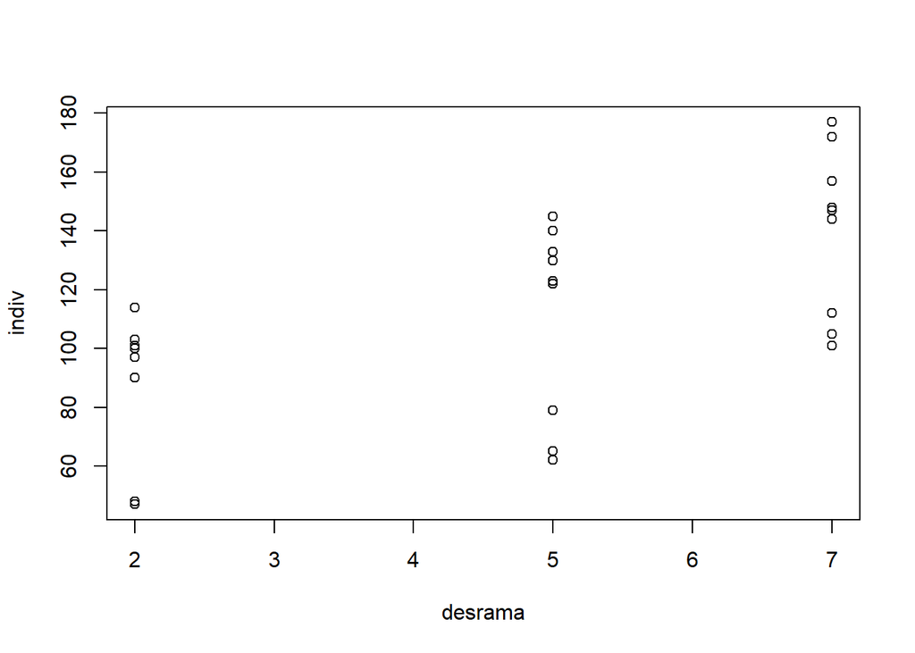

```r
# Considerando apenas tratamento secundário
plot(data = sub, indiv ~ desrama)
```

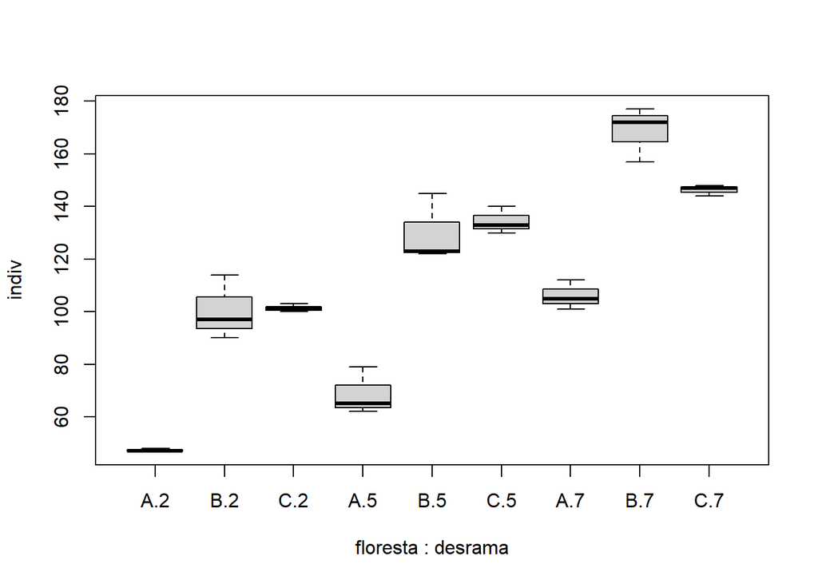

```r
# Interação dos tratamentos
boxplot(data = sub, indiv ~ floresta/desrama)
```

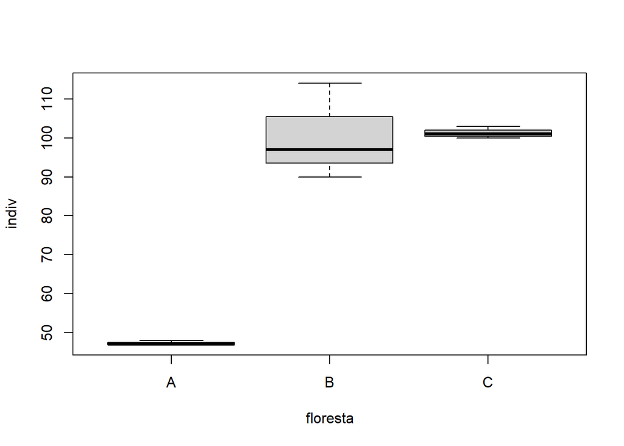

```r
# Isolando os níveis de desrana
# Fixando desrana até 2 metros
boxplot(data = sub[sub$desrama == 2,], indiv ~ floresta)
```

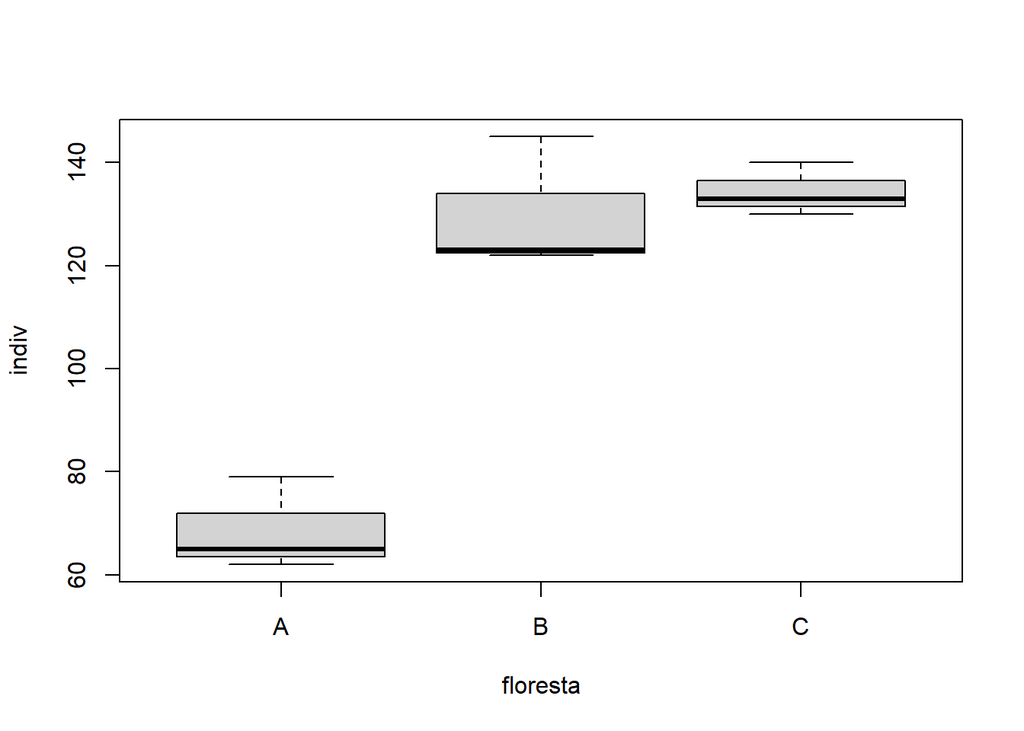

```r
# Fixando desrana até 5 metros
boxplot(data = sub[sub$desrama == 5,], indiv ~ floresta)
```

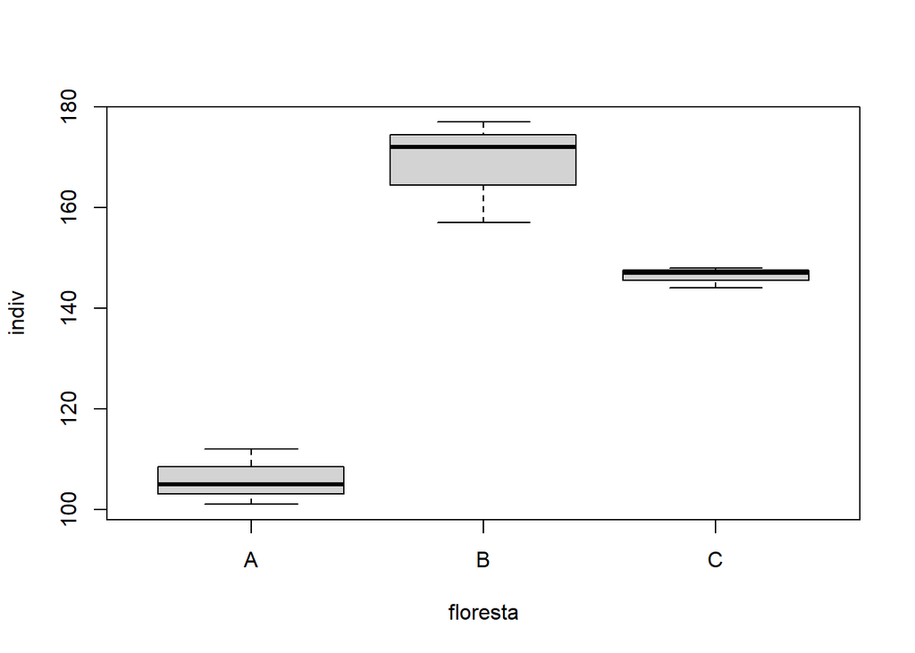

```r
# Fixando desrana até 7 metros
boxplot(data = sub[sub$desrama == 7,], indiv ~ floresta)
```

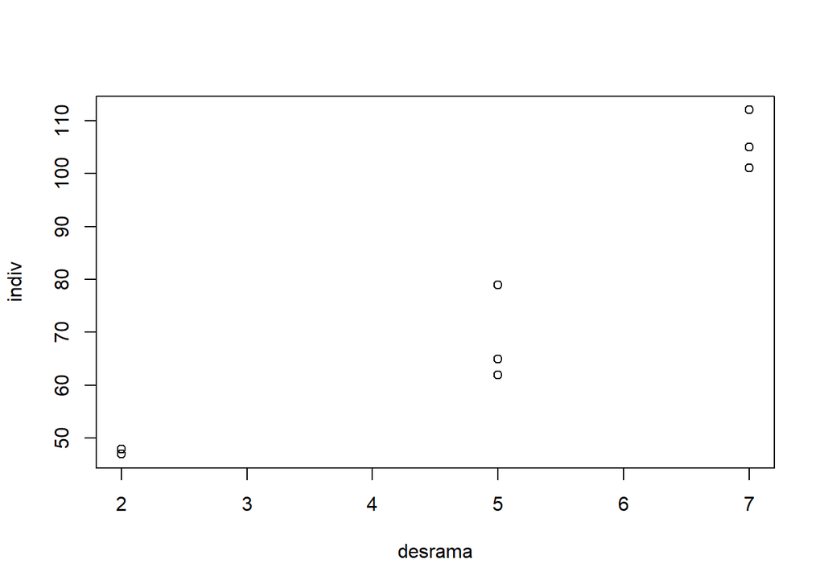

```r
# Isolando os tipos de floresta
# Fixando floresta igual a A
plot(data = sub[sub$floresta == "A",], indiv ~ desrama)
```

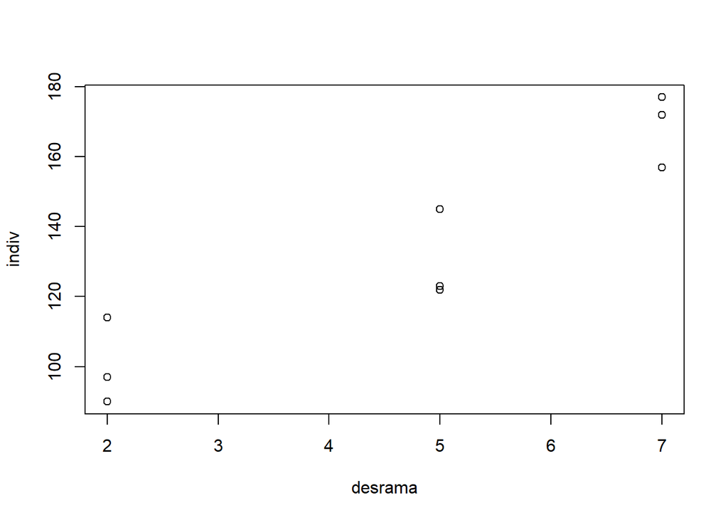

```r
# Fixando floresta igual a B
plot(data = sub[sub$floresta == "B",], indiv ~ desrama)
```

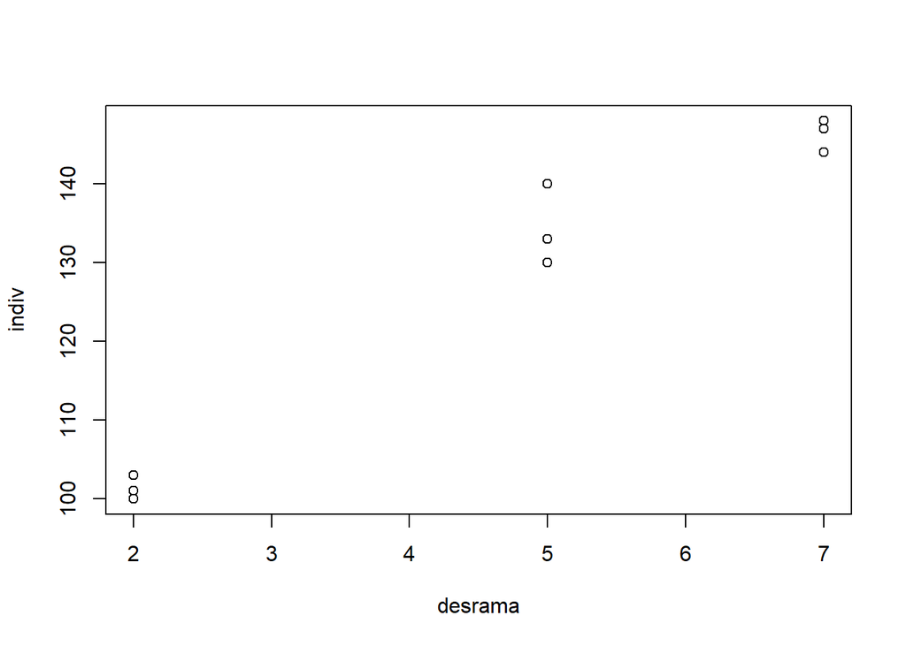

```r
# Fixando floresta igual a C
plot(data = sub[sub$floresta == "C",], indiv ~ desrama)
```

Analisando os gráficos acima, os fatores parecem significativos, assim como a interação. Os dados apresentam-se consistentes, sem a presença pontos fora da tendência. Infelizmente o pacote ExpDes.pt não inclui as análises de pressuposição para o delineamento de parcelas subdivididas. Existem várias maneiras de contornar esta questão, uma delas é combinar as qualidades de diferentes pacotes. Aqui por exemplo, podemos rodar a ANOVA a partir de ambos os pacotes easyanova e ExpDes.pt. Assim podemos utilizar os testes estatísticos das pressuposições de um e a ANOVA e desdobramentos do outro.

```r
require(easyanova)
r.aov = ea2(sub, design=4)
```

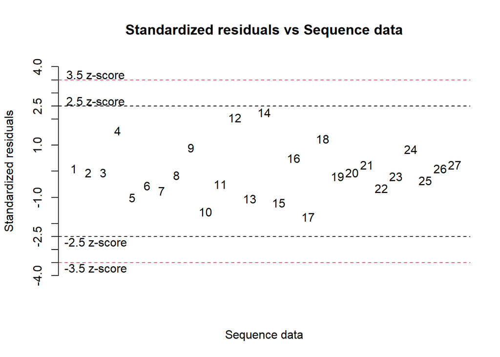

```r
r.aov[1]
```

```
## $`Marginal anova (Type III Sum of Squares)`
##                 numDF denDF   F-value p-value
## plot                2     6 267.37381  <.0001
## split.plot          2    12  94.56819  <.0001
## plot:split.plot     4    12   2.55256  0.0935
```

Como já vimos anteriormente, o teste de normalidade e de homogeneidade de variâncias pode ser obtida através da posição 10 da lista de resultados da função easyanova.

```r
r.aov[10]
```

```
## $`Residual analysis`
## $`Residual analysis`$values
##                                           values
## p.value Shapiro-Wilk test                 0.4583
## p.value Bartlett test (plot)              0.0036
## p.value Bartlett test (split.plot)        0.5945
## p.value Bartlett test (plot*split.plot)   0.0264
## AIC                                     171.9126
## BIC                                     182.5971
## first value most discrepant              14.0000
## second value most discrepant             12.0000
## third value most discrepant              17.0000
## Mean Square of Error a                   35.6667
## Mean Square of Error b                   64.0009
## Coefficient of Variation a                5.3589
## Coefficient of Variation b                7.1785
##
## $`Residual analysis`$residuals
##           1           2           3           4           5           6
##   0.6605916  -0.3252332  -0.3353584  10.3272582  -6.6585666  -3.6686917
##           7           8           9          10          11          12
##  -5.0060751  -0.9918999   5.9979750 -10.3191581  -3.3333333  13.6524915
##          13          14          15          16          17          18
##  -6.9858248  15.0000000  -8.0141752   3.3475085 -11.6666667   8.3191581
##          19          20          21          22          23          24
##  -1.3252332  -0.3323208   1.6575540  -4.3252332  -1.3323208   5.6575540
##          25          26          27
##  -2.3252332   0.6676792   1.6575540
## attr(,"label")
## [1] "Residuals"
##
## $`Residual analysis`$`standardized residuals`
##           1           2           3           4           5           6
##  0.09926874 -0.04887361 -0.05039514  1.55190283 -1.00059939 -0.55130344
##           7           8           9          10          11          12
## -0.75227538 -0.14905527  0.90133065 -1.55068561 -0.50090831  2.05159391
##          13          14          15          16          17          18
## -1.04977730  2.25408738 -1.20431008  0.50303845 -1.75317907  1.25014062
##          19          20          21          22          23          24
## -0.19914610 -0.04993868  0.24908478 -0.64996357 -0.20021117  0.85017474
##          25          26          27
## -0.34941859  0.10033381  0.24908478
```

A sintaxe da função para análise de parcela subdividida no pacote ExpDes.pt é:

```r
psub2.dic(fator1, fator2, repet, resp, quali = c(TRUE, TRUE),
          mcomp = "tukey", fac.names = c("F1", "F2"),
          sigT = 0.05, sigF = 0.05)
```

No nosso exemplo temos o fator principal (fator 1) como qualitativo e o fator secundário (fator 2) como quantitativo. Assim informando os parâmetros obrigatórios juntamente com os parâmetros quali e fac.names (nomes dos fatores) temos:

```r
require(ExpDes.pt)
psub2.dic(sub$floresta, sub$desrama, sub$rep, sub$indiv,
          quali = c(TRUE, FALSE),
          fac.names = c("Floresta", "Desrama"))
```

[output not shown]

[output cut: 33 more lines]

```
## R2 do modelo quadratico
## -
## 1
## -
##
## Analise de variancia do modelo quadratico
## ==============================================================
##                      GL     SQ          QM        Fc   valor.p
## --------------------------------------------------------------
## Efeito linear        1  14,552.1400 14,552.1400 186.04    0
## Efeito quadratico    1   242.5263    242.5263    3.1   0.10371
## Desvios de Regressao 0       0           0        0       1
## Residuos             12  938.6667     78.2222
## --------------------------------------------------------------
## ------------------------------------------------------------------------
```

Como esperado significância dos fatores: floresta e desrama. No entanto, a interação não foi significativa a 5%. Desta forma, não é necessário analisar a interação entre os fatores.

## O caso desbalanceado

Neste exemplo desbalanceado vamos analisar um experimento em que três alturas de desrama são subdivididos em três espécies florestais. O efeito dos tratamentos foi medido através da produção de madeira em metros cúbicos.

Dados de outro experimento em parcela subdividida, porém desbalanceado.

| especie | rep | desrama | volume |
| --- | --- | --- | --- |
| A | 1 | 2 | 48 |
| A | 3 | 2 | 47 |
| A | 1 | 5 | 79 |
| A | 2 | 5 | 62 |
| A | 3 | 5 | 65 |
| A | 1 | 7 | 131 |
| A | 2 | 7 | 65 |
| A | 3 | 7 | 112 |
| B | 1 | 2 | 80 |
| B | 2 | 2 | 97 |
| B | 3 | 2 | 114 |
| B | 1 | 5 | 123 |
| B | 2 | 5 | 145 |
| B | 3 | 5 | 122 |
| B | 1 | 7 | 172 |
| B | 2 | 7 | 157 |
| B | 3 | 7 | 177 |
| C | 1 | 2 | 100 |
| C | 3 | 2 | 103 |
| C | 2 | 5 | 133 |
| C | 3 | 5 | 104 |
| C | 2 | 7 | 147 |
| C | 3 | 7 | 119 |

O primeiro passo é importar o arquivo csv contendo os resultados do experimento para dentro do R. Esta tarefa pode ser realizada através do seguinte comando:

```r
sub2 = read.csv("./data/Experimento Subdividida 2.csv", sep = ",", dec = ".")
```

Os dados devem ser explorados graficamente antes de seguir com a análise de variância do experimento. Veja os gráficos abaixo e tente antecipar os resultados dos testes estatísticos.

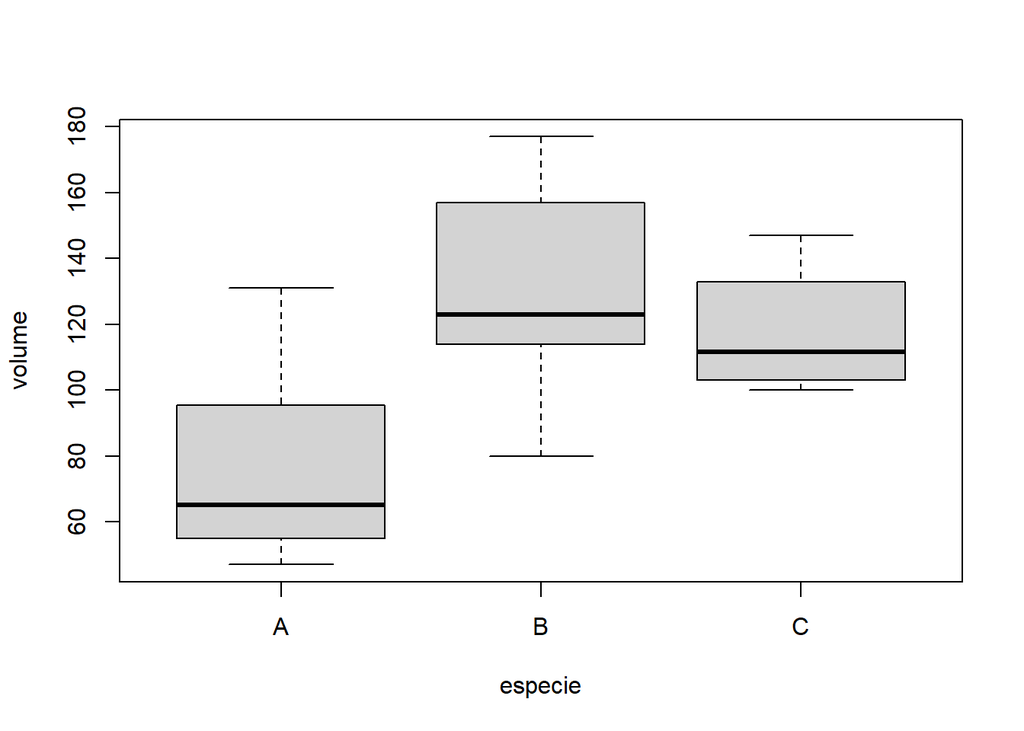

```r
# Considerando apenas tratamento principal
boxplot(data = sub2, volume ~ especie)
```

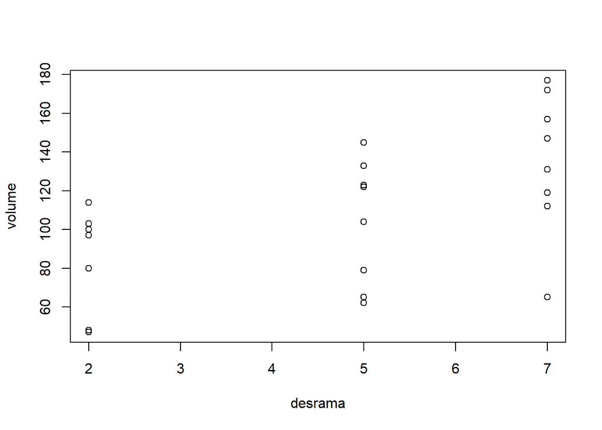

```r
# Considerando apenas tratamento secundário
plot(data = sub2, volume ~ desrama)
```

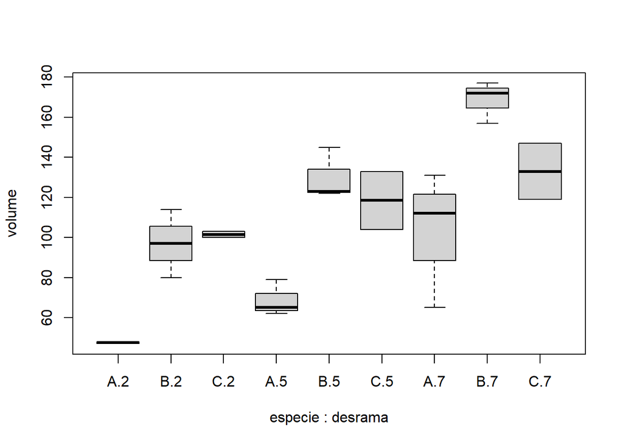

```r
# Interação dos tratamentos
boxplot(data = sub2, volume ~ especie/desrama)
```

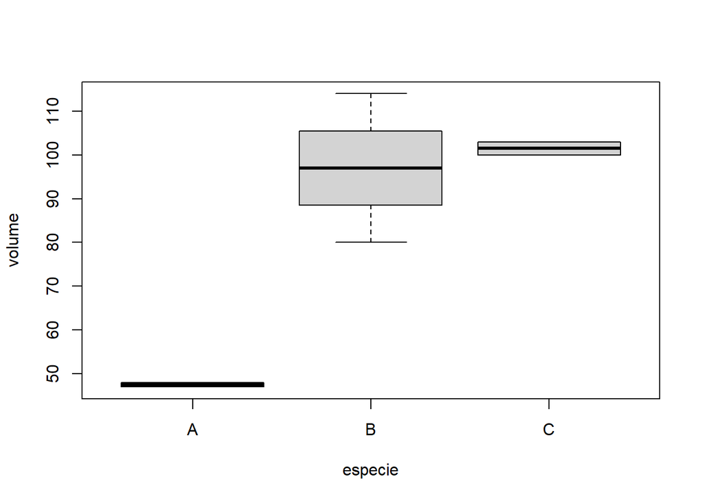

```r
# Isolando os níveis de desrama
# Fixando desrana até 2 metros
boxplot(data = sub2[sub2$desrama == 2,], volume ~ especie)
```

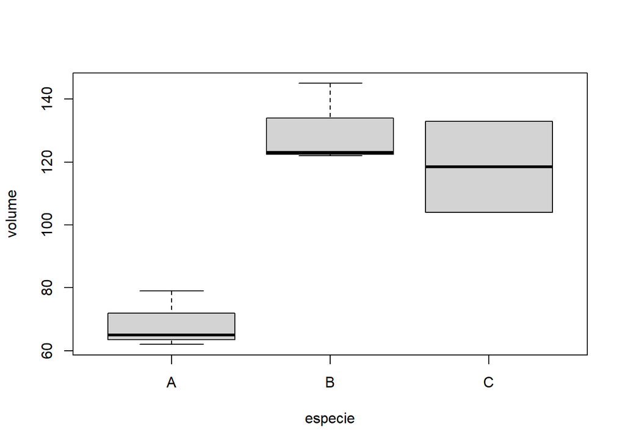

```r
# Fixando desrama até 5 metros
boxplot(data = sub2[sub2$desrama == 5,], volume ~ especie)
```

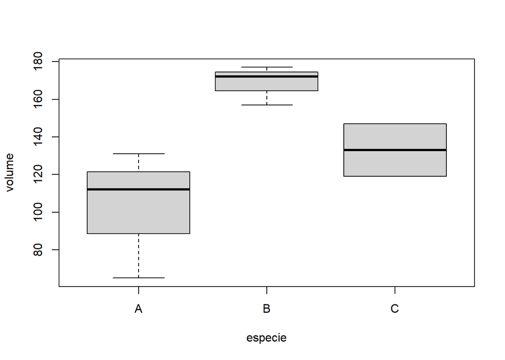

```r
# Fixando desrama até 7 metros
boxplot(data = sub2[sub2$desrama == 7,], volume ~ especie)
```

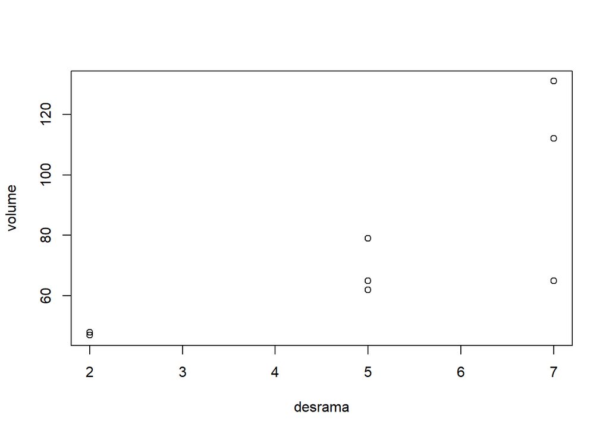

```r
# Isolando os tipos de floresta
# Fixando espécie igual a A
plot(data = sub2[sub2$especie == "A",], volume ~ desrama)
```

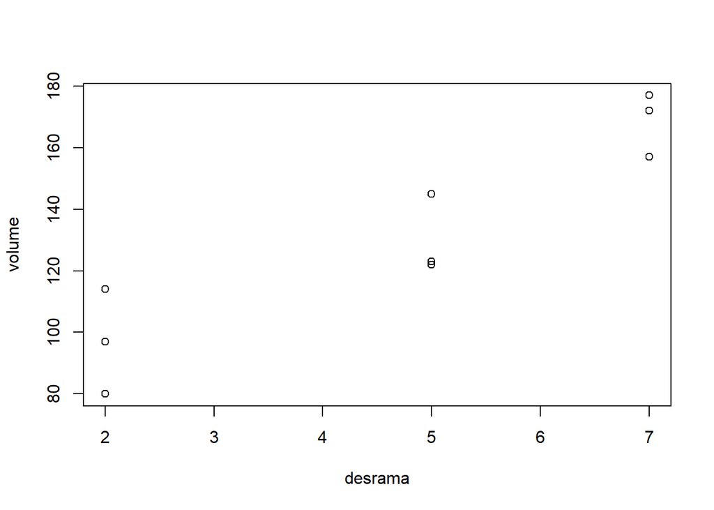

```r
# Fixando espécie igual a B
plot(data = sub2[sub2$especie == "B",], volume ~ desrama)
```

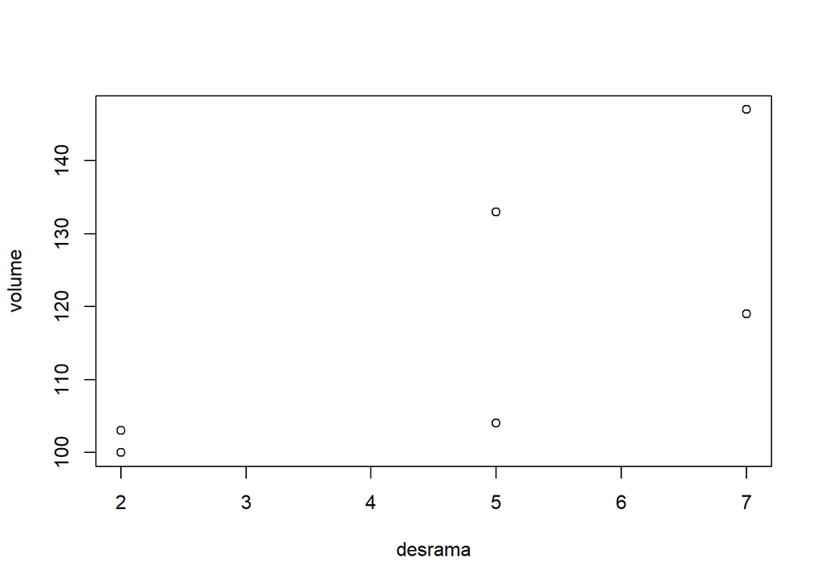

```r
# Fixando espécie igual a C
plot(data = sub2[sub2$especie == "C",], volume ~ desrama)
```

```r
ea2(data, design = 1, alpha = 0.05, cov = 4, list = FALSE,
    p.adjust=1, plot=2)
```

Os dados devem ser apresentados na ordem:

1. Fator nas parcelas
2. Repetição
3. Fator nas subparcelas
4. Variável resposta

O parâmetro design deve ser ajustado para 4, resultando no seguinte comando:

```r
require(easyanova)
r.aov = ea2(sub2, design=4)
```

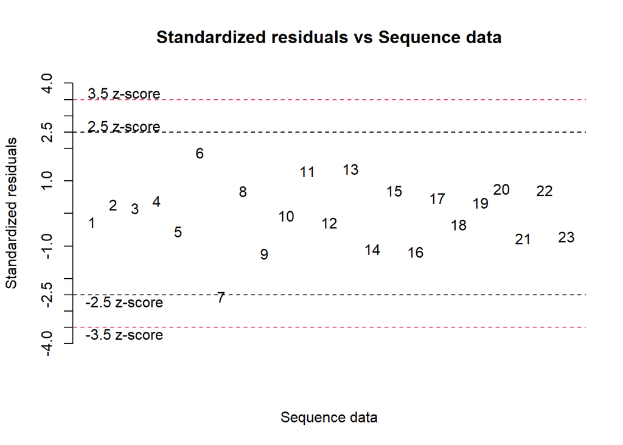

Os resultados podem ser acessados escolhendo qual elemento da lista deseja ser visualizado:

```r
r.aov[10]
```

```
## $`Residual analysis`
## $`Residual analysis`$values
##                                           values
## p.value Shapiro-Wilk test                 0.8313
## p.value Bartlett test (plot)              0.4160
## p.value Bartlett test (split.plot)        0.2427
## p.value Bartlett test (plot*split.plot)   0.6827
## AIC                                     165.0415
## BIC                                     172.7102
## first value most discrepant               7.0000
## second value most discrepant              6.0000
## third value most discrepant              13.0000
## Mean Square of Error a                  402.7662
## Mean Square of Error b                  220.3501
## Coefficient of Variation a               18.4488
## Coefficient of Variation b               13.6457
##
## $`Residual analysis`$residuals
##           1           2           3           4           5           6
##  -2.8241221   2.8241221   1.6212788   4.1091983  -5.7304770  19.6212788
##           7           8           9          10          11          12
## -26.8908017   7.2695230 -12.9589104  -0.6517886  13.6106990  -2.9589104
##          13          14          15          16          17          18
##  14.3482114 -11.3893010   7.3744229 -12.3184553   4.9440324  -3.5066019
##          19          20          21          22          23
##   3.5066019   7.9988237  -7.9988237   7.4988237  -7.4988237
## attr(,"label")
## [1] "Residuals"
##
## $`Residual analysis`$`standardized residuals`
##           1           2           3           4           5           6
## -0.26911379  0.26911379  0.15449349  0.39157015 -0.54606364  1.86973386
##           7           8           9          10          11          12
## -2.56245492  0.69272107 -1.23486923 -0.06210968  1.29697891 -0.28195792
##          13          14          15          16          17          18
##  1.36725729 -1.08529938  0.70271711 -1.17383954  0.47112244 -0.33414806
##          19          20          21          22          23
##  0.33414806  0.76221696 -0.76221696  0.71457139 -0.71457139
```

```
O teste de normalidade apresentou valor não significativo, indicando assim que não há evidências para rejeitar a normalidade dos resíduos.
```

```r
r.aov[1]
```

```
## $`Marginal anova (Type III Sum of Squares)`
##                 numDF denDF  F-value p-value
## plot                2     6 16.07861  0.0039
## split.plot          2     8 21.60633  0.0006
## plot:split.plot     4     8  1.27547  0.3555
```

Sendo a interação não significativa, os fatores (da parcela e da subparcela) devem ser analisados independentemente.

```r
# Comparação das parcelas
r.aov[2]
```

```
## $`Adjusted means (plot)`
##   plot adjusted.mean standard.error tukey snk duncan t
## 1    B      131.8889         7.6958     a   a      a a
## 2    C      118.3355         8.6638     a   a      a a
## 3    A       71.1485         8.0186     b   b      b b
```

```r
# Comparação das subdivisões
r.aov[4]
```

```
## $`Adjusted means (split.plot)`
##   split.plot adjusted.mean standard.error tukey snk duncan t
## 1          7      134.5013         6.4491     a   a      a a
## 2          5      105.4458         6.4491     b   b      b b
## 3          2       81.4258         6.8129     c   c      c c
```